# Latihan Pertemuan 4

Muhammad Daffa Fadhilah Athif

2026-09-17

# 1 Pendahuluan

Pada latihan ini, dibangkitkan tiga jenis proses time series sebanyak **300 data**, yaitu MA(2), AR(2), dan ARMA(2,2), masing-masing dengan dua metode pembangkitan (manual dan `arima.sim`). Untuk setiap proses dilakukan:

1. Plot time series, ACF, PACF, dan EACF untuk identifikasi kestasioneran dan orde model.
2. Uji formal kestasioneran (Augmented Dickey-Fuller).
3. Scatterplot $Y_t$ terhadap $Y_{t-1}$, $Y_{t-2}$, dan $Y_{t-3}$.
4. Perbandingan autokorelasi empiris (dari data) dengan autokorelasi teoritis (dari rumus model).

# 2 Proses MA(2)

## 2.1 Membangkitkan Data

### 2.1.1 a. Cara Manual

```r
n <- 300
theta1 <- 0.4
theta2 <- 0.6

set.seed(111)
et <- rnorm(n + 2, mean = 0, sd = 1)   # 2 nilai error tambahan sbg "burn-in"

y_ma_manual <- numeric(n)
for (t in 1:n) {
  y_ma_manual[t] <- et[t + 2] + theta1 * et[t + 1] + theta2 * et[t]
}
ma2_manual <- ts(y_ma_manual)
```

### 2.1.2 b. Menggunakan `arima.sim`

```r
set.seed(111)
ma2_sim <- arima.sim(model = list(ma = c(theta1, theta2)), n = n)
```

## 2.2 Plot Time Series

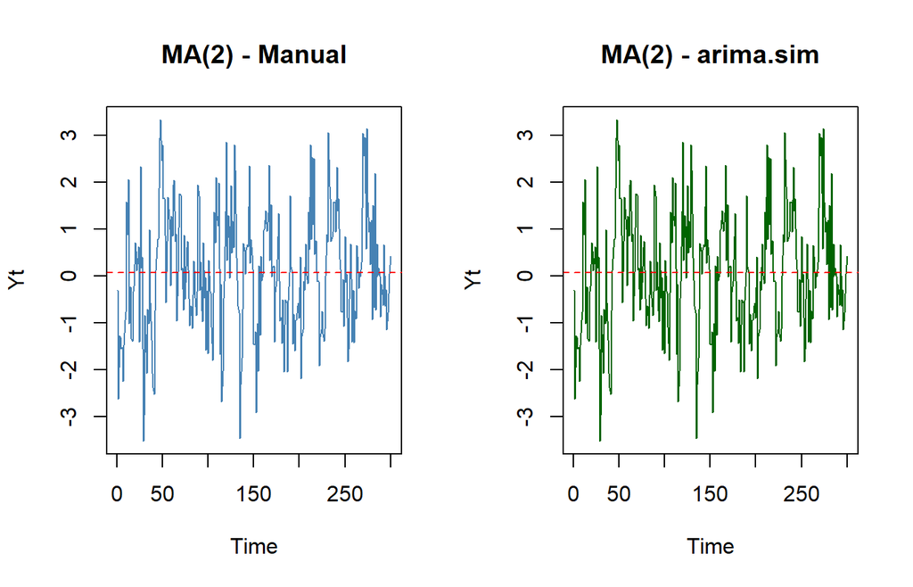

```r
par(mfrow = c(1, 2))
plot.ts(ma2_manual, main = "MA(2) - Manual", ylab = "Yt", col = "steelblue")
abline(h = mean(ma2_manual), col = "red", lty = 2)
plot.ts(ma2_sim, main = "MA(2) - arima.sim", ylab = "Yt", col = "darkgreen")
abline(h = mean(ma2_sim), col = "red", lty = 2)
```

**Interpretasi:** Kedua plot menunjukkan data berfluktuasi di sekitar rata-rata konstan (mendekati nol) tanpa pola tren maupun perubahan varians yang sistematis sepanjang waktu. Ini merupakan indikasi awal bahwa proses **stasioner dalam rata-rata dan varians**.

## 2.3 Plot ACF, PACF, dan EACF

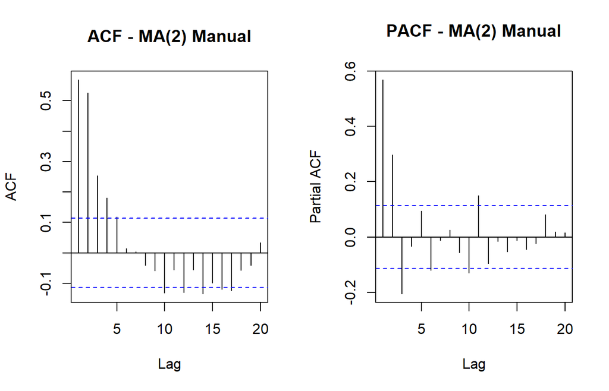

```r
par(mfrow = c(1, 2))
acf(ma2_manual, main = "ACF - MA(2) Manual", lag.max = 20)
pacf(ma2_manual, main = "PACF - MA(2) Manual", lag.max = 20)
```

```r
eacf(ma2_manual)
```

```
## AR/MA
##   0 1 2 3 4 5 6 7 8 9 10 11 12 13
## 0 x x x x x o o o o x o  x  o  x
## 1 x x x o o o o o o x o  x  o  x
## 2 x x x o o o o o o o o  o  o  o
## 3 x x o x x o o o o o o  o  o  o
## 4 x o x o o o o o o o o  o  o  o
## 5 x x x x o o o o o o o  o  o  o
## 6 o x x o o o o o o o o  o  o  o
## 7 x o x x o o o o o o o  o  o  o
```

## 2.4 Uji Formal Kestasioneran

```r
adf.test(ma2_manual)
```

```
##
##  Augmented Dickey-Fuller Test
##
## data:  ma2_manual
## Dickey-Fuller = -5.8357, Lag order = 6, p-value = 0.01
## alternative hypothesis: stationary
```

**Interpretasi:** Nilai p-value dari uji ADF < 0.05, sehingga tolak $H_0$ (ada akar unit). Artinya data **stasioner**, sejalan dengan sifat proses MA yang selalu stasioner untuk sembarang nilai parameter $\theta$.

## 2.5 Scatterplot $Y_t$ vs $Y_{t-k}$

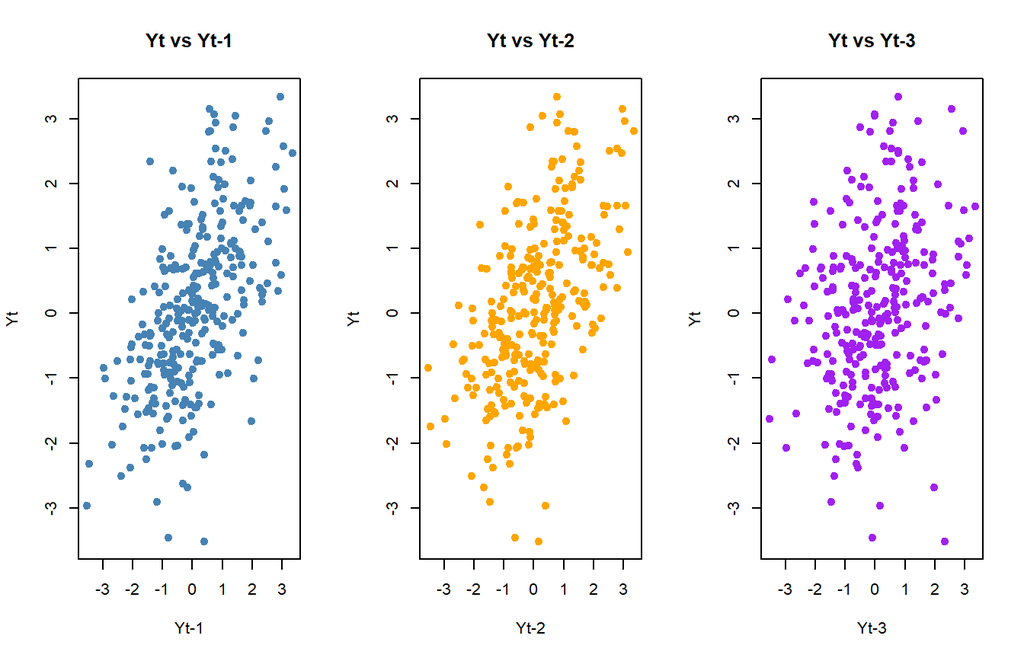

```r
par(mfrow = c(1, 3))
n_ma <- length(ma2_manual)

plot(ma2_manual[1:(n_ma-1)], ma2_manual[2:n_ma],
     xlab = "Yt-1", ylab = "Yt", main = "Yt vs Yt-1", pch = 19, col = "steelblue")
plot(ma2_manual[1:(n_ma-2)], ma2_manual[3:n_ma],
     xlab = "Yt-2", ylab = "Yt", main = "Yt vs Yt-2", pch = 19, col = "orange")
plot(ma2_manual[1:(n_ma-3)], ma2_manual[4:n_ma],
     xlab = "Yt-3", ylab = "Yt", main = "Yt vs Yt-3", pch = 19, col = "purple")
```

## 2.6 Autokorelasi: Empiris vs Teoritis

```r
acf_empiris_ma <- acf(ma2_manual, plot = FALSE, lag.max = 5)$acf[2:6]
acf_teoritis_ma <- ARMAacf(ma = c(theta1, theta2), lag.max = 5)[2:6]

data.frame(
  Lag = 1:5,
  Empiris = round(acf_empiris_ma, 4),
  Teoritis = round(acf_teoritis_ma, 4)
)
```

[output not shown]

# 3 Proses AR(2)

Model: $Y_t = \phi_1 Y_{t-1} + \phi_2 Y_{t-2} + e_t$, dengan $\phi_1 = 0.5$ dan $\phi_2 = 0.2$.

## 3.1 Membangkitkan Data

### 3.1.1 a. Cara Manual

```r
n <- 300
burn <- 100   # periode pembuangan (burn-in) agar efek nilai awal hilang
phi1 <- 0.5
phi2 <- 0.2

set.seed(222)
et <- rnorm(n + burn)
y_ar_manual <- numeric(n + burn)
y_ar_manual[1] <- et[1]
y_ar_manual[2] <- et[2]
for (t in 3:(n + burn)) {
  y_ar_manual[t] <- phi1 * y_ar_manual[t-1] + phi2 * y_ar_manual[t-2] + et[t]
}
ar2_manual <- ts(y_ar_manual[(burn+1):(n+burn)])
```

### 3.1.2 b. Menggunakan `arima.sim`

```r
set.seed(222)
ar2_sim <- arima.sim(model = list(ar = c(phi1, phi2)), n = n)
```

## 3.2 Plot Time Series

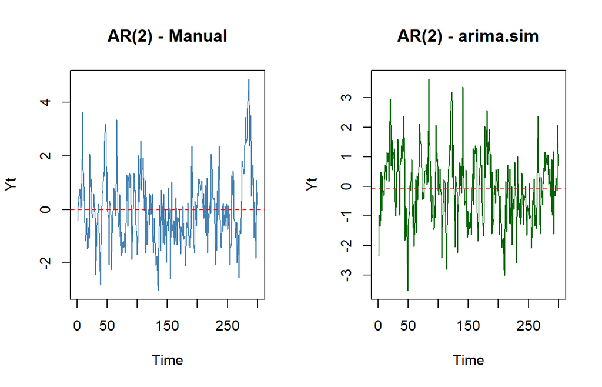

```r
par(mfrow = c(1, 2))
plot.ts(ar2_manual, main = "AR(2) - Manual", ylab = "Yt", col = "steelblue")
abline(h = mean(ar2_manual), col = "red", lty = 2)
plot.ts(ar2_sim, main = "AR(2) - arima.sim", ylab = "Yt", col = "darkgreen")
abline(h = mean(ar2_sim), col = "red", lty = 2)
```

**Interpretasi:** Kedua deret berfluktuasi di sekitar rata-rata konstan tanpa tren, mengindikasikan kestasioneran. Ini sesuai dengan syarat kestasioneran AR(2): $\phi_1+\phi_2<1$, $\phi_2-\phi_1<1$, $|\phi_2|<1$, yang terpenuhi untuk $\phi_1=0.5, \phi_2=0.2$.

## 3.3 Plot ACF, PACF, dan EACF

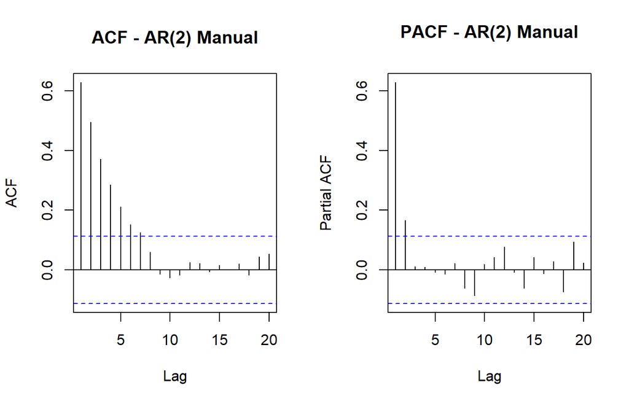

```r
par(mfrow = c(1, 2))
acf(ar2_manual, main = "ACF - AR(2) Manual", lag.max = 20)
pacf(ar2_manual, main = "PACF - AR(2) Manual", lag.max = 20)
```

```r
eacf(ar2_manual)
```

```
## AR/MA
##   0 1 2 3 4 5 6 7 8 9 10 11 12 13
## 0 x x x x x x x o o o o  o  o  o
## 1 x o o o o o o o o o o  o  o  o
## 2 o o o o o o o o o o o  o  o  o
## 3 x o o o o o o o o o o  o  o  o
## 4 x x o o o o o o o o o  o  o  o
## 5 x x o o o o o o o o o  o  o  o
## 6 x o x o o o o o o o o  o  o  o
## 7 x o x o x o o o o o o  o  o  o
```

**Interpretasi:**

- **ACF** *tails off* (menurun secara eksponensial/gradual), tidak cut off tajam — ciri khas proses AR.
- **PACF** signifikan pada lag 1 dan 2, lalu *cut off* setelah lag 2 — sesuai dengan orde AR(2).
- **EACF** menunjukkan segitiga nol dimulai pada baris AR=2, kolom MA=0, mengonfirmasi orde **(p,q) = (2,0)**.

## 3.4 Uji Formal Kestasioneran

```r
adf.test(ar2_manual)
```

```
##
##  Augmented Dickey-Fuller Test
##
## data:  ar2_manual
## Dickey-Fuller = -4.8098, Lag order = 6, p-value = 0.01
## alternative hypothesis: stationary
```

**Interpretasi:** p-value < 0.05 sehingga $H_0$ (data memiliki akar unit/tidak stasioner) ditolak. Data **stasioner**, konsisten dengan parameter $\phi_1, \phi_2$ yang berada di dalam kawasan kestasioneran AR(2).

## 3.5 Scatterplot $Y_t$ vs $Y_{t-k}$

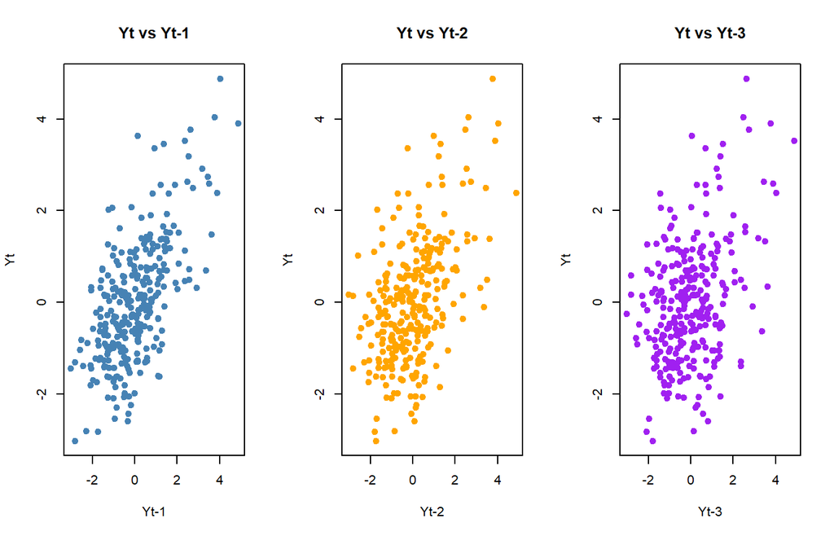

```r
par(mfrow = c(1, 3))
n_ar <- length(ar2_manual)

plot(ar2_manual[1:(n_ar-1)], ar2_manual[2:n_ar],
     xlab = "Yt-1", ylab = "Yt", main = "Yt vs Yt-1", pch = 19, col = "steelblue")
plot(ar2_manual[1:(n_ar-2)], ar2_manual[3:n_ar],
     xlab = "Yt-2", ylab = "Yt", main = "Yt vs Yt-2", pch = 19, col = "orange")
plot(ar2_manual[1:(n_ar-3)], ar2_manual[4:n_ar],
     xlab = "Yt-3", ylab = "Yt", main = "Yt vs Yt-3", pch = 19, col = "purple")
```

**Interpretasi:** Berbeda dengan MA(2), pada AR(2) hubungan linear antara $Y_t$ dan lag-lag sebelumnya tetap terlihat hingga lag 3 (meski semakin melemah), karena pada proses AR ketergantungan antar-observasi berlaku untuk semua lag (ACF tidak cut off, melainkan tails off menuju nol secara perlahan).

## 3.6 Autokorelasi: Empiris vs Teoritis

```r
acf_empiris_ar <- acf(ar2_manual, plot = FALSE, lag.max = 5)$acf[2:6]
acf_teoritis_ar <- ARMAacf(ar = c(phi1, phi2), lag.max = 5)[2:6]

data.frame(
  Lag = 1:5,
  Empiris = round(acf_empiris_ar, 4),
  Teoritis = round(acf_teoritis_ar, 4)
)
```

[output not shown]

**Interpretasi:** Autokorelasi empiris mengikuti pola menurun yang sama dengan autokorelasi teoritis (tails off, tidak langsung nol), dengan selisih nilai yang relatif kecil pada setiap lag — mengonfirmasi bahwa data hasil pembangkitan konsisten dengan model AR(2) teoritisnya.

# 4 Proses ARMA(2,2)

Model: $Y_t = \phi_1 Y_{t-1} + \phi_2 Y_{t-2} + e_t + \theta_1 e_{t-1} + \theta_2 e_{t-2}$, dengan $\phi_1=0.5$, $\phi_2=0.2$, $\theta_1=0.4$, $\theta_2=0.6$.

## 4.1 Membangkitkan Data

### 4.1.1 a. Cara Manual

```r
n <- 300
burn <- 100
phi1 <- 0.5; phi2 <- 0.2
theta1 <- 0.4; theta2 <- 0.6

set.seed(333)
et <- rnorm(n + burn + 2)   # +2 utk inisialisasi komponen MA
y_arma_manual <- numeric(n + burn)
y_arma_manual[1] <- et[3]
y_arma_manual[2] <- et[4]
for (t in 3:(n + burn)) {
  y_arma_manual[t] <- phi1 * y_arma_manual[t-1] + phi2 * y_arma_manual[t-2] +
    et[t+2] + theta1 * et[t+1] + theta2 * et[t]
}
arma22_manual <- ts(y_arma_manual[(burn+1):(n+burn)])
```

### 4.1.2 b. Menggunakan `arima.sim`

```r
set.seed(333)
arma22_sim <- arima.sim(model = list(ar = c(phi1, phi2), ma = c(theta1, theta2)), n = n)
```

## 4.2 Plot Time Series

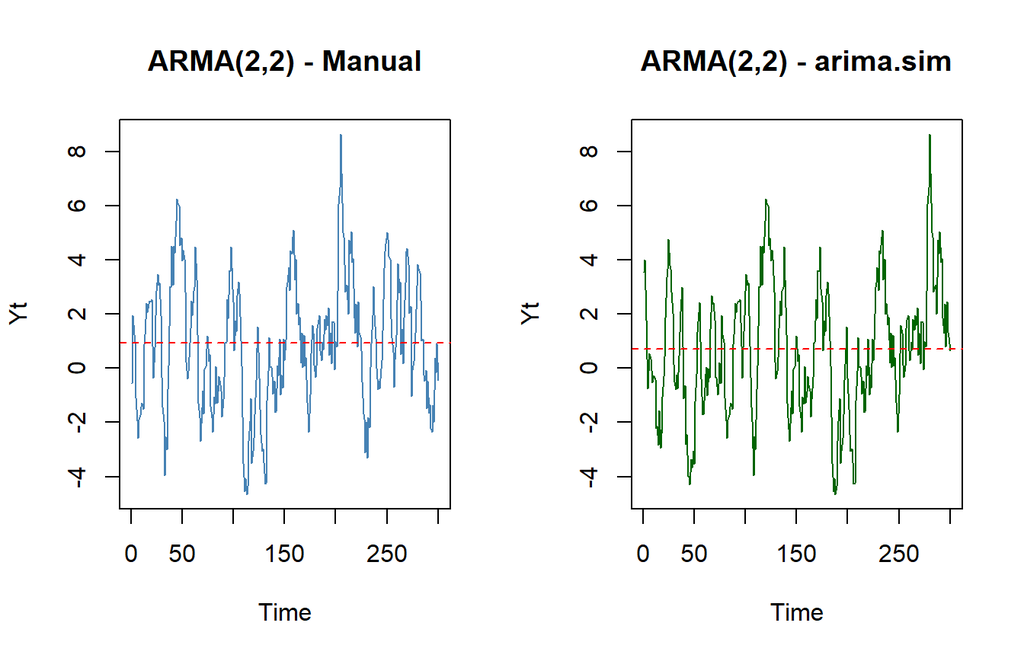

```r
par(mfrow = c(1, 2))
plot.ts(arma22_manual, main = "ARMA(2,2) - Manual", ylab = "Yt", col = "steelblue")
abline(h = mean(arma22_manual), col = "red", lty = 2)
plot.ts(arma22_sim, main = "ARMA(2,2) - arima.sim", ylab = "Yt", col = "darkgreen")
abline(h = mean(arma22_sim), col = "red", lty = 2)
```

**Interpretasi:** Data berfluktuasi stabil di sekitar rata-rata konstan tanpa tren maupun perubahan varians yang mencolok, mengindikasikan proses stasioner (parameter AR memenuhi syarat kestasioneran).

## 4.3 Plot ACF, PACF, dan EACF

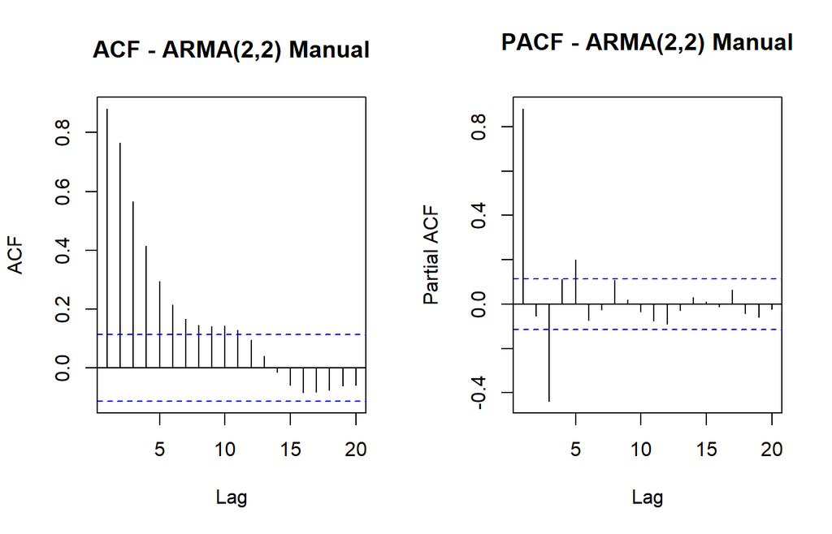

```r
par(mfrow = c(1, 2))
acf(arma22_manual, main = "ACF - ARMA(2,2) Manual", lag.max = 20)
pacf(arma22_manual, main = "PACF - ARMA(2,2) Manual", lag.max = 20)
```

```r
eacf(arma22_manual)
```

```
## AR/MA
##   0 1 2 3 4 5 6 7 8 9 10 11 12 13
## 0 x x x x x x x x x x x  o  o  o
## 1 o x o o o o o o o o o  o  o  o
## 2 x x x o o o o o o o o  o  o  o
## 3 x x x x o o o o o o o  o  o  o
## 4 x x x o o o o o o o o  o  o  o
## 5 x x x o o o o o o o o  o  o  o
## 6 x x x o o o x o o o o  o  o  o
## 7 x x x o x x x x o o o  o  o  o
```

## 4.4 Uji Formal Kestasioneran

```r
adf.test(arma22_manual)
```

```
##
##  Augmented Dickey-Fuller Test
##
## data:  arma22_manual
## Dickey-Fuller = -4.4302, Lag order = 6, p-value = 0.01
## alternative hypothesis: stationary
```

**Interpretasi:** p-value < 0.05, sehingga $H_0$ ditolak dan data disimpulkan **stasioner**, sesuai dengan parameter AR yang berada dalam kawasan kestasioneran.

## 4.5 Scatterplot $Y_t$ vs $Y_{t-k}$

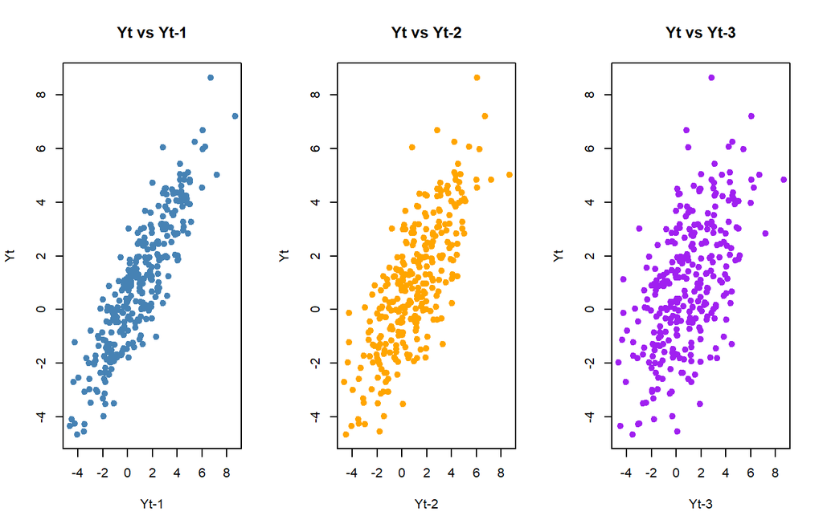

```r
par(mfrow = c(1, 3))
n_arma <- length(arma22_manual)

plot(arma22_manual[1:(n_arma-1)], arma22_manual[2:n_arma],
     xlab = "Yt-1", ylab = "Yt", main = "Yt vs Yt-1", pch = 19, col = "steelblue")
plot(arma22_manual[1:(n_arma-2)], arma22_manual[3:n_arma],
     xlab = "Yt-2", ylab = "Yt", main = "Yt vs Yt-2", pch = 19, col = "orange")
plot(arma22_manual[1:(n_arma-3)], arma22_manual[4:n_arma],
     xlab = "Yt-3", ylab = "Yt", main = "Yt vs Yt-3", pch = 19, col = "purple")
```

**Interpretasi:** Pola hubungan linear masih terlihat pada ketiga lag, meski melemah seiring bertambahnya lag — konsekuensi dari komponen AR yang membuat ACF tidak langsung nol (tails off), diperkuat oleh kontribusi komponen MA pada lag-lag awal.

## 4.6 Autokorelasi: Empiris vs Teoritis

```r
acf_empiris_arma <- acf(arma22_manual, plot = FALSE, lag.max = 5)$acf[2:6]
acf_teoritis_arma <- ARMAacf(ar = c(phi1, phi2), ma = c(theta1, theta2), lag.max = 5)[2:6]

data.frame(
  Lag = 1:5,
  Empiris = round(acf_empiris_arma, 4),
  Teoritis = round(acf_teoritis_arma, 4)
)
```

[output not shown]

**Interpretasi:** Autokorelasi teoritis ARMA(2,2) dihitung menggunakan fungsi `ARMAacf()` yang menyelesaikan sistem persamaan gabungan komponen AR dan MA. Nilai empiris hasil pembangkitan data cukup konsisten dengan nilai teoritisnya pada tiap lag, mengonfirmasi kesesuaian data simulasi dengan model ARMA(2,2) yang ditentukan.

# 5 Kesimpulan Umum